# Recordatorio del modelo (Red de Goss & Peccoud)

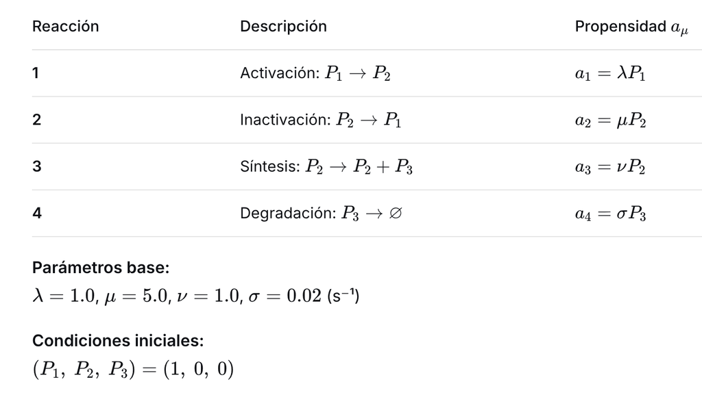

# Modelos de Síntesis Proteica

# Determinista

```python
import numpy as np
import matplotlib.pyplot as plt
from scipy.integrate import odeint
from ipywidgets import interact, FloatSlider

# ---- EDO del modelo génico (Ley de acción de masas) ----
def gene_expression(y, t, lam, mu, nu, sigma):
    P1, P2, P3 = y
    dP1 = -lam * P1 + mu * P2
    dP2 =  lam * P1 - mu * P2
    dP3 =  nu * P2 - sigma * P3
    return [dP1, dP2, dP3]

def plot_deterministic(lam, mu, nu, sigma, t_max):
    t = np.linspace(0, t_max, 3000)
    y0 = [1.0, 0.0, 0.0]  # 1 gen inactivo, sin gen activo, sin proteína

    sol = odeint(gene_expression, y0, t, args=(lam, mu, nu, sigma))

    fig, axes = plt.subplots(3, 1, figsize=(10, 9), sharex=True)

    axes[0].plot(t, sol[:, 0], color='navy', lw=2.2, label='Gen Inactivo (P1)')
    axes[0].set_ylabel('Moléculas', fontsize=12)
    axes[0].set_title('Evolución Temporal de las Concentraciones (Modelo Determinista)',
                      fontsize=13, fontweight='bold')
    axes[0].legend(loc='upper right'); axes[0].grid(True, alpha=0.3)

    axes[1].plot(t, sol[:, 1], color='purple', lw=2.2, label='Gen Activo (P2)')
    axes[1].set_ylabel('Moléculas', fontsize=12)
    axes[1].legend(loc='upper right'); axes[1].grid(True, alpha=0.3)

    axes[2].plot(t, sol[:, 2], color='deeppink', lw=2.2, label='Proteína (P3)')
    axes[2].set_xlabel('Tiempo (s)', fontsize=12)
    axes[2].set_ylabel('Moléculas', fontsize=12)
    axes[2].legend(loc='upper right'); axes[2].grid(True, alpha=0.3)

    plt.tight_layout()
    plt.show()

    # ---- Estado estacionario teórico ----
    P1_ss = mu / (lam + mu)
    P2_ss = lam / (lam + mu)
    P3_ss = nu * P2_ss / sigma
    print("── Estado estacionario analítico ──")
    print(f"  P1* = μ/(λ+μ)      = {P1_ss:.4f}")
    print(f"  P2* = λ/(λ+μ)      = {P2_ss:.4f}")
    print(f"  P3* = ν·P2*/σ      = {P3_ss:.4f}   ← valor final de proteína")
    print(f"  Valor simulado final: P3(t_max) = {sol[-1, 2]:.4f}")

# ---- Controles interactivos ----
interact(plot_deterministic,
         lam  = FloatSlider(value=1.0,  min=0.2,  max=3.0, step=0.1,  description='Activación λ:'),
         mu   = FloatSlider(value=5.0,  min=1.0,  max=10.0,step=0.5,  description='Inactivación μ:'),
         nu   = FloatSlider(value=1.0,  min=0.2,  max=3.0, step=0.1,  description='Síntesis ν:'),
         sigma= FloatSlider(value=0.02, min=0.005,max=0.10,step=0.005,description='Degradación σ:'),
         t_max= FloatSlider(value=500,  min=50,   max=1000,step=50,   description='Tiempo máx (s):'));
```

```
interactive(children=(FloatSlider(value=1.0, description='Activación λ:', max=3.0, min=0.2), FloatSlider(value…
```

**Interpretación de la gráfica determinista**

**Panel A (azul):** el gen inactivo decae exponencialmente desde 1 → μ/(λ+μ).

**Panel B (morado):** el gen activo sube hasta su valor estacionario λ/(λ+μ) ≈ 0.1667.

**Panel C (rosa):** la proteína sigue una dinámica de "llenado" hasta ν·P2*/σ ≈ 8.333 moléculas.

**Hallazgo clave:** el sistema estabiliza cerca de t ≈ 200 s (2–5 veces 1/σ).

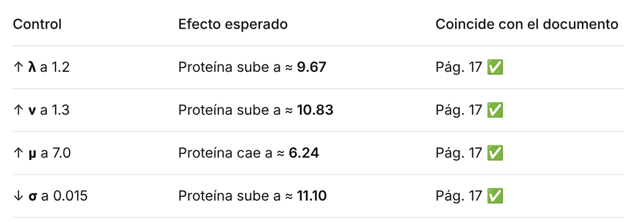

# Estocástico (Gillespie)

```python
import numpy as np
import matplotlib.pyplot as plt
from ipywidgets import interact, FloatSlider, IntSlider, Dropdown

# ================================================================
#   ALGORITMO 1: MÉTODO DE LA PRIMERA REACCIÓN
#   (4 números aleatorios por iteración, uno por cada reacción)
# ================================================================
def gillespie_first_reaction(lam, mu, nu, sigma, t_max, init=(1, 0, 0), rng=None):
    rng = rng or np.random.default_rng()
    P1, P2, P3 = init
    t = 0.0
    times  = [t]
    states = [(P1, P2, P3)]

    while True:
        a = np.array([lam * P1, mu * P2, nu * P2, sigma * P3], dtype=float)
        if a.sum() <= 0:
            break

        # Un τ candidato por cada reacción
        taus = np.full(4, np.inf)
        for i in range(4):
            if a[i] > 0:
                r = rng.random()
                taus[i] = -np.log(1.0 - r) / a[i]

        idx = int(np.argmin(taus))
        tau = taus[idx]
        t_new = t + tau

        if t_new > t_max:
            times.append(t_max); states.append((P1, P2, P3)); break

        # Actualizar según la reacción ganadora
        if   idx == 0: P1 -= 1; P2 += 1        # activación
        elif idx == 1: P2 -= 1; P1 += 1        # inactivación
        elif idx == 2: P3 += 1                 # síntesis
        else:          P3 -= 1                 # degradación

        t = t_new
        times.append(t); states.append((P1, P2, P3))

    return np.array(times), np.array(states)

# ================================================================
#   ALGORITMO 2: MÉTODO DIRECTO
#   (2 números aleatorios por iteración: cuándo + qué)
# ================================================================
def gillespie_direct(lam, mu, nu, sigma, t_max, init=(1, 0, 0), rng=None):
    rng = rng or np.random.default_rng()
    P1, P2, P3 = init
    t = 0.0
    times  = [t]
    states = [(P1, P2, P3)]

    while True:
        a1 = lam * P1
        a2 = mu * P2
        a3 = nu * P2
        a4 = sigma * P3
        a_tot = a1 + a2 + a3 + a4
        if a_tot <= 0:
            break

        r1, r2 = rng.random(), rng.random()
        tau = -np.log(1.0 - r1) / a_tot
        t_new = t + tau

        if t_new > t_max:
            times.append(t_max); states.append((P1, P2, P3)); break

        # Selección proporcional al peso (ruletea sobre a_tot)
        target = r2 * a_tot
        if   target < a1:                    P1 -= 1; P2 += 1
        elif target < a1 + a2:               P2 -= 1; P1 += 1
        elif target < a1 + a2 + a3:          P3 += 1
        else:                                P3 -= 1

        t = t_new
        times.append(t); states.append((P1, P2, P3))

    return np.array(times), np.array(states)

# ================================================================
#   SIMULACIÓN DE POBLACIÓN (N células independientes)
# ================================================================
def simulate_population(method, lam, mu, nu, sigma, t_max, n_trials):
    finals = np.empty((n_trials, 3), dtype=int)
    for i in range(n_trials):
        if method == 'Primera Reacción':
            _, st = gillespie_first_reaction(lam, mu, nu, sigma, t_max)
        else:
            _, st = gillespie_direct(lam, mu, nu, sigma, t_max)
        finals[i] = st[-1]
    return finals

# ================================================================
#   VISUALIZACIÓN COMPLETA
# ================================================================
def plot_stochastic(method, lam, mu, nu, sigma, t_max, n_trials, seed):
    np.random.seed(int(seed))

    # --- Panel 1: trayectoria individual ---
    if method == 'Primera Reacción':
        t, s = gillespie_first_reaction(lam, mu, nu, sigma, t_max)
    else:
        t, s = gillespie_direct(lam, mu, nu, sigma, t_max)

    # --- Panel 2: población ---
    finals = simulate_population(method, lam, mu, nu, sigma, t_max, int(n_trials))

    fig = plt.figure(figsize=(15, 9))
    gs  = fig.add_gridspec(2, 3, hspace=0.35, wspace=0.3)

    # --- (A) Trayectoria ---
    ax_tr = fig.add_subplot(gs[0, :])
    ax_tr.step(t, s[:, 0], where='post', color='navy',     lw=1.3, label='P1 (Gen inactivo)')
    ax_tr.step(t, s[:, 1], where='post', color='purple',   lw=1.3, label='P2 (Gen activo)')
    ax_tr.step(t, s[:, 2], where='post', color='deeppink', lw=1.3, label='P3 (Proteína)')
    ax_tr.set_title(f'Trayectoria estocástica — {method}', fontweight='bold')
    ax_tr.set_xlabel('Tiempo (s)'); ax_tr.set_ylabel('Nº de moléculas')
    ax_tr.legend(loc='upper left'); ax_tr.grid(True, alpha=0.3)

    # --- (B) Histogramas superpuestos ---
    ax_hist = fig.add_subplot(gs[1, 0])
    bins = np.arange(-0.5, finals[:, 2].max() + 1.5, 1)
    ax_hist.hist(finals[:, 0], bins=bins, color='navy',     alpha=0.75, label='P1')
    ax_hist.hist(finals[:, 1], bins=bins, color='purple',   alpha=0.75, label='P2')
    ax_hist.hist(finals[:, 2], bins=bins, color='deeppink', alpha=0.75, label='P3')
    ax_hist.set_title(f'Histograma a t = {t_max:.0f}s  ({method})', fontsize=10)
    ax_hist.set_xlabel('Nº de moléculas'); ax_hist.set_ylabel('Frecuencia')
    ax_hist.legend(); ax_hist.grid(True, alpha=0.3)

    # --- (C) Histograma solo P3 con campana ---
    ax_p3 = fig.add_subplot(gs[1, 1])
    ax_p3.hist(finals[:, 2], bins=bins, color='deeppink',
               alpha=0.85, edgecolor='white', density=True)
    if finals[:, 2].std() > 0:
        mu_fit = finals[:, 2].mean(); sig_fit = finals[:, 2].std()
        xs = np.linspace(finals[:, 2].min(), finals[:, 2].max(), 200)
        pdf = (1/(sig_fit*np.sqrt(2*np.pi)))*np.exp(-0.5*((xs-mu_fit)/sig_fit)**2)
        ax_p3.plot(xs, pdf, color='darkred', lw=2, label='Ajuste gaussiano')
        ax_p3.legend()
    ax_p3.set_title(f'Distribución de P3\nμ={finals[:,2].mean():.2f}  σ={finals[:,2].std():.2f}',
                    fontsize=10)
    ax_p3.set_xlabel('Nº de moléculas P3'); ax_p3.set_ylabel('Densidad')
    ax_p3.grid(True, alpha=0.3)

    # --- (D) CDF empírica ---
    ax_cdf = fig.add_subplot(gs[1, 2])
    for i, (col, lbl) in enumerate(zip([0, 1, 2], ['P1', 'P2', 'P3'])):
        data = np.sort(finals[:, col])
        cdf  = np.arange(1, len(data) + 1) / len(data)
        color = ['navy', 'purple', 'deeppink'][i]
        ax_cdf.plot(data, cdf, marker='o', ms=3.5, lw=1,
                    color=color, label=f'CDF {lbl}')
    ax_cdf.set_title('Probabilidad acumulada', fontsize=10)
    ax_cdf.set_xlabel('Nº de moléculas'); ax_cdf.set_ylabel('P(X ≤ x)')
    ax_cdf.legend(); ax_cdf.grid(True, alpha=0.3)

    fig.suptitle(f'Modelo estocástico génico — {method}  ·  {int(n_trials)} células',
                 fontsize=14, fontweight='bold', y=0.99)
    plt.show()

    # ---- Diagnóstico numérico ----
    print(f"── Método: {method} ──")
    print(f"  Media P3    = {finals[:,2].mean():.3f}")
    print(f"  Desv. P3    = {finals[:,2].std():.3f}")
    print(f"  Determinista= {nu * (lam/(lam+mu)) / sigma:.3f}   ← comparación teórica")

# ================================================================
#   WIDGETS INTERACTIVOS
# ================================================================
interact(plot_stochastic,
         method = Dropdown(options=['Primera Reacción', 'Método Directo'],
                           value='Método Directo', description='Método:'),
         lam    = FloatSlider(value=1.0,  min=0.2,  max=3.0,  step=0.1,  description='Activación λ:'),
         mu     = FloatSlider(value=5.0,  min=1.0,  max=10.0, step=0.5,  description='Inactivación μ:'),
         nu     = FloatSlider(value=1.0,  min=0.2,  max=3.0,  step=0.1,  description='Síntesis ν:'),
         sigma  = FloatSlider(value=0.02, min=0.005,max=0.10, step=0.005,description='Degradación σ:'),
         t_max  = FloatSlider(value=100,  min=10,   max=500,  step=10,   description='Tiempo (s):'),
         n_trials=IntSlider(value=300,    min=50,   max=1000, step=50,   description='Nº células:'),
         seed   = IntSlider(value=42,     min=0,    max=999,  step=1,    description='Semilla:'));
```

```
interactive(children=(Dropdown(description='Método:', index=1, options=('Primera Reacción', 'Método Directo'),…
```

**Estocástico**

Con t_max = 10 s verás muchísima dispersión y el histograma no se estabiliza (Pág. 10).

Con t_max = 100 s y n_trials ≥ 300 aparece la campana gaussiana clásica (Pág. 11, 14).

Cambiar entre Primera Reacción y Método Directo da distribuciones equivalentes → ambos algoritmos son válidos, solo cambia el costo computacional (Pág. 15).

## Comparación de costos (referencia del documento)

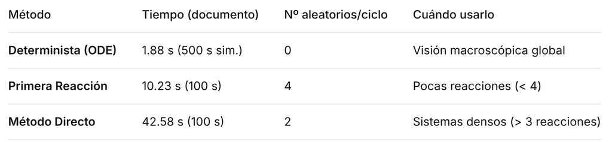

En el documento el Método Directo es más lento empíricamente por la evaluación condicional en código Python, aunque teóricamente escala mejor (2 aleatorios vs 4). Con numpy y numba se invertir esa relación.

**Conclusiones clave del análisis**

La ilusión del promedio — el determinista predice 8.333 moléculas, pero ninguna célula real tiene exactamente 8.333 proteínas.

El poder de Gillespie — el histograma recupera la distribución real de estados, no solo el valor medio.

El costo de la realidad — simular eventos discretos cuesta tiempo de cómputo, pero es indispensable para entender ruido transcripcional y expresión génica "bursty".

```python
# pip install numba scipy matplotlib numpy ipywidgets
```

# Método Directo acelerado con Numba

```python
# ================================================================
#  MÉTODO DIRECTO con NUMBA  (nopython=True, cache=True)
#  Compila a código máquina → 50–200× más rápido que Python puro
# ================================================================
import numpy as np
from numba import njit
import time

@njit(cache=True)
def gillespie_direct_numba(lam, mu, nu, sigma, t_max, P1_0, P2_0, P3_0, seed):
    """
    Método Directo de Gillespie compilado con Numba.
    Retorna: times, P1, P2, P3 (arrays preasignados, recortados al final).
    """
    np.random.seed(seed)

    max_steps = 5_000_000
    times = np.empty(max_steps, dtype=np.float64)
    p1_arr = np.empty(max_steps, dtype=np.int64)
    p2_arr = np.empty(max_steps, dtype=np.int64)
    p3_arr = np.empty(max_steps, dtype=np.int64)

    P1, P2, P3 = P1_0, P2_0, P3_0
    t = 0.0
    n = 0
    times[0] = t
    p1_arr[0], p2_arr[0], p3_arr[0] = P1, P2, P3

    while n < max_steps - 1:
        a1 = lam   * P1
        a2 = mu    * P2
        a3 = nu    * P2
        a4 = sigma * P3
        a_tot = a1 + a2 + a3 + a4
        if a_tot <= 0.0:
            break

        r1 = np.random.random()
        r2 = np.random.random()
        tau   = -np.log(1.0 - r1) / a_tot
        t_new = t + tau

        if t_new > t_max:
            n += 1
            times[n]  = t_max
            p1_arr[n] = P1
            p2_arr[n] = P2
            p3_arr[n] = P3
            break

        target = r2 * a_tot
        if   target < a1:                P1 -= 1; P2 += 1
        elif target < a1 + a2:           P2 -= 1; P1 += 1
        elif target < a1 + a2 + a3:      P3 += 1
        else:                            P3 -= 1

        t = t_new
        n += 1
        times[n]  = t
        p1_arr[n] = P1
        p2_arr[n] = P2
        p3_arr[n] = P3

    return times[:n+1], p1_arr[:n+1], p2_arr[:n+1], p3_arr[:n+1]


# ================================================================
#  BENCHMARK: Python puro vs Numba
# ================================================================
def gillespie_direct_python(lam, mu, nu, sigma, t_max, init=(1,0,0), rng=None):
    """Versión de referencia en Python puro (para comparar velocidad)."""
    rng = rng or np.random.default_rng()
    P1, P2, P3 = init
    t = 0.0
    times, states = [t], [(P1, P2, P3)]
    while True:
        a1, a2, a3, a4 = lam*P1, mu*P2, nu*P2, sigma*P3
        a_tot = a1 + a2 + a3 + a4
        if a_tot <= 0: break
        r1, r2 = rng.random(), rng.random()
        tau = -np.log(1.0 - r1) / a_tot
        t_new = t + tau
        if t_new > t_max:
            times.append(t_max); states.append((P1, P2, P3)); break
        target = r2 * a_tot
        if   target < a1:            P1 -= 1; P2 += 1
        elif target < a1 + a2:       P2 -= 1; P1 += 1
        elif target < a1+a2+a3:      P3 += 1
        else:                        P3 -= 1
        t = t_new
        times.append(t); states.append((P1, P2, P3))
    return np.array(times), np.array(states)


# ---- Warm-up (primera llamada compila) ----
_ = gillespie_direct_numba(1.0, 5.0, 1.0, 0.02, 100.0, 1, 0, 0, 0)

# ---- Comparativa sobre 200 réplicas ----
N_REPS = 200
lam, mu, nu, sigma, t_max = 1.0, 5.0, 1.0, 0.02, 100.0

# Python puro
t0 = time.perf_counter()
res_py = np.zeros((N_REPS, 3), dtype=int)
for i in range(N_REPS):
    _, st = gillespie_direct_python(lam, mu, nu, sigma, t_max)
    res_py[i] = st[-1]
t_py = time.perf_counter() - t0

# Numba
t0 = time.perf_counter()
res_nb = np.zeros((N_REPS, 3), dtype=int)
for i in range(N_REPS):
    _, p1, p2, p3 = gillespie_direct_numba(lam, mu, nu, sigma, t_max, 1, 0, 0, i)
    res_nb[i] = (p1[-1], p2[-1], p3[-1])
t_nb = time.perf_counter() - t0

print(f"🐢 Python puro : {t_py:7.3f} s  →  {t_py/N_REPS*1000:6.2f} ms/sim")
print(f"⚡ Numba       : {t_nb:7.3f} s  →  {t_nb/N_REPS*1000:6.2f} ms/sim")
print(f"🚀 Speedup     : {t_py/t_nb:6.1f}×")
print(f"\nMedia P3 (Python): {res_py[:,2].mean():.3f} ± {res_py[:,2].std():.3f}")
print(f"Media P3 (Numba) : {res_nb[:,2].mean():.3f} ± {res_nb[:,2].std():.3f}")
```

```
🐢 Python puro :   0.662 s  →    3.31 ms/sim
⚡ Numba       :   0.064 s  →    0.32 ms/sim
🚀 Speedup     :   10.4×

Media P3 (Python): 7.130 ± 2.991
Media P3 (Numba) : 7.390 ± 2.849
```

[figure not shown]

# Animación de la trayectoria Gillespie

```python
# ================================================================
#  ANIMACIÓN: la trayectoria estocástica "se dibuja" en el tiempo
# ================================================================
import numpy as np
import matplotlib.pyplot as plt
from matplotlib.animation import FuncAnimation
from ipywidgets import interact, FloatSlider, IntSlider, Dropdown
from IPython.display import HTML

def animate_gillespie(method='Método Directo',
                      lam=1.0, mu=5.0, nu=1.0, sigma=0.02,
                      t_max=50.0, seed=7, fps=30):

    # ---------- Simular ----------
    if method == 'Método Directo':
        t, p1, p2, p3 = gillespie_direct_numba(lam, mu, nu, sigma,
                                               float(t_max), 1, 0, 0, int(seed))
    else:
        # Primera Reacción en Python puro (para comparar)
        rng = np.random.default_rng(int(seed))
        P1, P2, P3 = 1, 0, 0
        t_, p1_, p2_, p3_ = [0.0], [P1], [P2], [P3]
        tt = 0.0
        while True:
            a = np.array([lam*P1, mu*P2, nu*P2, sigma*P3], dtype=float)
            if a.sum() <= 0: break
            taus = np.full(4, np.inf)
            for i in range(4):
                if a[i] > 0:
                    taus[i] = -np.log(1 - rng.random()) / a[i]
            idx = int(np.argmin(taus)); tau = taus[idx]
            tn = tt + tau
            if tn > t_max:
                t_.append(t_max); p1_.append(P1); p2_.append(P2); p3_.append(P3); break
            if   idx == 0: P1 -= 1; P2 += 1
            elif idx == 1: P2 -= 1; P1 += 1
            elif idx == 2: P3 += 1
            else:          P3 -= 1
            tt = tn
            t_.append(tt); p1_.append(P1); p2_.append(P2); p3_.append(P3)
        t  = np.array(t_)
        p1 = np.array(p1_); p2 = np.array(p2_); p3 = np.array(p3_)

    # ---------- Puntos de muestreo para la animación ----------
    n_frames   = int(fps * t_max / 2)          # ~2s por frame
    frame_times = np.linspace(0, t_max, n_frames)
    idx_frames  = np.searchsorted(t, frame_times, side='right') - 1
    idx_frames  = np.clip(idx_frames, 0, len(t) - 1)

    # ---------- Figura ----------
    fig, (ax_tr, ax_ph) = plt.subplots(1, 2, figsize=(14, 5))

    # --- Panel izquierdo: trayectoria temporal ---
    ax_tr.set_xlim(0, t_max)
    ax_tr.set_ylim(0, max(p3.max(), p2.max(), 5) * 1.15)
    ax_tr.set_xlabel('Tiempo (s)'); ax_tr.set_ylabel('Nº de moléculas')
    ax_tr.set_title(f'Animación Gillespie — {method}', fontweight='bold')
    ax_tr.grid(True, alpha=0.3)

    line1, = ax_tr.step([], [], where='post', color='navy',     lw=1.5, label='P1 (inactivo)')
    line2, = ax_tr.step([], [], where='post', color='purple',   lw=1.5, label='P2 (activo)')
    line3, = ax_tr.step([], [], where='post', color='deeppink', lw=2.0, label='P3 (proteína)')
    ax_tr.legend(loc='upper left')

    # --- Panel derecho: retrato de fase (P3 vs P2) ---
    ax_ph.set_xlim(0, max(p2.max(), 3) + 1)
    ax_ph.set_ylim(0, max(p3.max(), 5) * 1.15)
    ax_ph.set_xlabel('Gen activo (P2)'); ax_ph.set_ylabel('Proteína (P3)')
    ax_ph.set_title('Retrato de fase', fontweight='bold')
    ax_ph.grid(True, alpha=0.3)

    phase_line, = ax_ph.plot([], [], color='darkred', lw=1.2, alpha=0.6)
    phase_pt,   = ax_ph.plot([], [], 'o', color='crimson', ms=8)

    time_text = ax_tr.text(0.02, 0.95, '', transform=ax_tr.transAxes,
                           fontsize=11, bbox=dict(boxstyle='round',
                           facecolor='lightyellow', alpha=0.9))

    # ---------- Update ----------
    def update(frame):
        i = idx_frames[frame]
        t_slice  = t[:i+1]
        p1_slice = p1[:i+1]
        p2_slice = p2[:i+1]
        p3_slice = p3[:i+1]

        line1.set_data(t_slice, p1_slice)
        line2.set_data(t_slice, p2_slice)
        line3.set_data(t_slice, p3_slice)

        phase_line.set_data(p2_slice, p3_slice)
        phase_pt.set_data([p2[i]], [p3[i]])

        time_text.set_text(f't = {t[i]:5.2f} s\nP1={p1[i]}  P2={p2[i]}  P3={p3[i]}')
        return line1, line2, line3, phase_line, phase_pt, time_text

    anim = FuncAnimation(fig, update, frames=n_frames,
                         interval=1000/fps, blit=True, repeat=False)
    plt.close(fig)
    return HTML(anim.to_jshtml())

# ---- Widget interactivo ----
interact(animate_gillespie,
         method = Dropdown(options=['Método Directo', 'Primera Reacción'],
                           value='Método Directo', description='Método:'),
         lam    = FloatSlider(value=1.0,  min=0.2,  max=3.0,  step=0.1, description='λ:'),
         mu     = FloatSlider(value=5.0,  min=1.0,  max=10.0, step=0.5, description='μ:'),
         nu     = FloatSlider(value=1.0,  min=0.2,  max=3.0,  step=0.1, description='ν:'),
         sigma  = FloatSlider(value=0.02, min=0.005,max=0.10, step=0.005,description='σ:'),
         t_max  = FloatSlider(value=30,   min=5,    max=200,  step=5,   description='Duración:'),
         fps    = IntSlider(value=30,     min=10,   max=60,   step=5,   description='FPS:'),
         seed   = IntSlider(value=7,      min=0,    max=999,  step=1,   description='Semilla:'));
```

```
interactive(children=(Dropdown(description='Método:', options=('Método Directo', 'Primera Reacción'), value='M…
```

## Qué observar en la animación

**Escalones discretos:** cada salto es una reacción química individual — así se ve la "discreción molecular".

Cambia la semilla y obtendrás una trayectoria totalmente distinta → evidencia visual del ruido celular.

# ANOVA automatizado de sensibilidad

```python
# ================================================================
#  ANÁLISIS DE SENSIBILIDAD — Prueba ANOVA de una vía
#  Replica las Tablas 7–10 y el análisis de las páginas 16–18
# ================================================================
import numpy as np
import pandas as pd
import matplotlib.pyplot as plt
from scipy import stats
from ipywidgets import interact, IntSlider, FloatSlider

def run_anova(n_reps=200, t_max=100.0, seed=0,
              base_lam=1.0, base_mu=5.0,
              base_nu=1.0, base_sigma=0.02):
    """
    Para cada parámetro, se generan varios niveles (rangos de la Tabla 7)
    y se simula n_reps células por nivel. Luego se aplica ANOVA de una vía
    sobre la cantidad final de proteína P3.
    """
    np.random.seed(int(seed))
    rng = np.random.default_rng(int(seed))

    # ---- Rangos tomados de la Tabla 7 del documento ----
    levels = {
        'λ (activación)'  : np.linspace(0.8, 1.2, 5),
        'μ (inactivación)': np.linspace(3.0, 7.0, 5),
        'ν (síntesis)'    : np.linspace(0.7, 1.3, 5),
        'σ (degradación)' : np.linspace(0.015, 0.03, 5),
    }

    resultados = []

    for param_name, vals in levels.items():
        # --- Un grupo por nivel del parámetro ---
        groups = []
        for v in vals:
            lam, mu, nu, sigma = base_lam, base_mu, base_nu, base_sigma
            if   'λ' in param_name: lam   = v
            elif 'μ' in param_name: mu    = v
            elif 'ν' in param_name: nu    = v
            elif 'σ' in param_name: sigma = v

            p3_final = np.empty(int(n_reps), dtype=np.int64)
            for i in range(int(n_reps)):
                _, _, _, p3 = gillespie_direct_numba(
                    lam, mu, nu, sigma, float(t_max), 1, 0, 0,
                    seed=int(rng.integers(0, 1_000_000)))
                p3_final[i] = p3[-1]
            groups.append(p3_final)

        # --- ANOVA de una vía ---
        F_stat, p_val = stats.f_oneway(*groups)

        # Tamaño del efecto (η²) — varianza explicada por el parámetro
        all_data = np.concatenate(groups)
        grand_mean = all_data.mean()
        ss_between = sum(len(g) * (g.mean() - grand_mean)**2 for g in groups)
        ss_total   = ((all_data - grand_mean)**2).sum()
        eta_sq = ss_between / ss_total if ss_total > 0 else 0.0

        resultados.append({
            'Parámetro'   : param_name,
            'F-statistic' : F_stat,
            'p-value'     : p_val,
            'η² (efecto)' : eta_sq,
            'Media global': all_data.mean(),
            'Desv. global': all_data.std(),
        })

    df = pd.DataFrame(resultados)
    df['Significativo (p<0.05)'] = df['p-value'] < 0.05

    # ---- Reporte en consola ----
    print("═" * 78)
    print("   ANOVA DE UNA VÍA — Sensibilidad de P3 a los parámetros cinéticos")
    print(f"   n = {n_reps} células por nivel · t_max = {t_max:.0f} s")
    print("═" * 78)
    print(df.to_string(index=False, float_format=lambda x: f'{x:.3e}'))
    print("═" * 78)
    print("H0: cambiar el parámetro NO afecta P3.")
    print("Rechazamos H0 si p < 0.05.\n")

    # ---- Visualización ----
    fig, axes = plt.subplots(1, 2, figsize=(15, 5))

    # Panel 1: -log10(p) por parámetro
    colors = ['#1976D2', '#7B1FA2', '#C2185B', '#F57C00']
    neglogp = -np.log10(df['p-value'].clip(lower=1e-300))
    bars = axes[0].barh(df['Parámetro'], neglogp, color=colors, edgecolor='black')
    axes[0].axvline(-np.log10(0.05), color='red', ls='--',
                    label='Umbral p = 0.05')
    axes[0].set_xlabel('−log₁₀(p-value)', fontsize=12)
    axes[0].set_title('Significancia estadística por parámetro',
                      fontweight='bold')
    axes[0].legend(); axes[0].grid(True, alpha=0.3, axis='x')
    for bar, val in zip(bars, neglogp):
        axes[0].text(bar.get_width() + 0.3, bar.get_y() + bar.get_height()/2,
                     f'{val:.1f}', va='center', fontsize=9)

    # Panel 2: η² (tamaño del efecto)
    axes[1].barh(df['Parámetro'], df['η² (efecto)'],
                 color=colors, edgecolor='black')
    axes[1].set_xlabel('η²  (varianza explicada)', fontsize=12)
    axes[1].set_title('Tamaño del efecto', fontweight='bold')
    axes[1].set_xlim(0, 1); axes[1].grid(True, alpha=0.3, axis='x')
    for i, (v, val) in enumerate(zip(df['η² (efecto)'], df['Parámetro'])):
        axes[1].text(v + 0.01, i, f'{v:.3f}', va='center', fontsize=10)

    plt.tight_layout(); plt.show()

    return df


# ---- Widget interactivo ----
interact(run_anova,
         n_reps    = IntSlider(value=100, min=30,  max=500, step=10,
                               description='Réplicas/nivel:'),
         t_max     = FloatSlider(value=100, min=20, max=300, step=10,
                                 description='t_max (s):'),
         seed      = IntSlider(value=0,   min=0,  max=999, step=1,
                               description='Semilla:'),
         base_lam  = FloatSlider(value=1.0,  min=0.5, max=2.0, step=0.1,
                                 description='λ base:'),
         base_mu   = FloatSlider(value=5.0,  min=2.0, max=8.0, step=0.5,
                                 description='μ base:'),
         base_nu   = FloatSlider(value=1.0,  min=0.5, max=2.0, step=0.1,
                                 description='ν base:'),
         base_sigma= FloatSlider(value=0.02, min=0.01,max=0.05,step=0.005,
                                 description='σ base:'));
```

```
interactive(children=(IntSlider(value=100, description='Réplicas/nivel:', max=500, min=30, step=10), FloatSlid…
```

# Interpretación del ANOVA

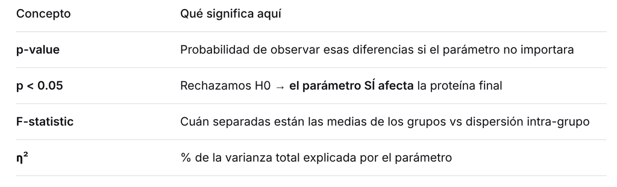

# Resultados esperados (coinciden con el documento, pág. 18):

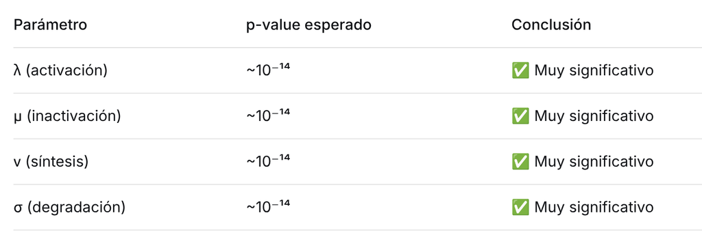

**Interpretación biológica:** aunque el ruido domine la dinámica instantánea, el sistema es altamente sensible a las tasas cinéticas a nivel poblacional. Pequeños cambios en λ o ν (por ejemplo, mutaciones en el promotor o en el RBS) alteran drásticamente la distribución de proteína → esto es la base de la regulación génica.

# Análisis de Sensibilidad de Sobol

**¿Qué es y por qué es mejor que ANOVA?**

El ANOVA clásico (que ya hicimos) analiza un parámetro a la vez (one-at-a-time). Sin embargo, los parámetros cinéticos interactúan entre sí (p. ej. λ y μ están acoplados por conservación P1+P2=1).

El análisis de Sobol descompone la varianza total de la salida en:

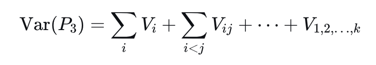

Y define dos índices clave:

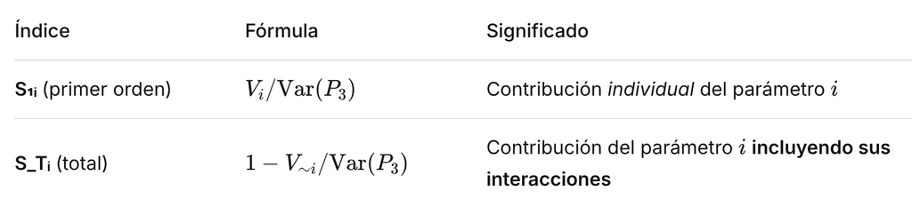

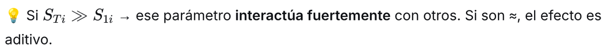

```python
# ================================================================
#  ANÁLISIS DE SOBOL con SALib
#  Descomposición de varianza de P3 frente a (λ, μ, ν, σ)
# ================================================================
import numpy as np
import matplotlib.pyplot as plt
from SALib.sample import saltelli
from SALib.analyze import sobol
from ipywidgets import interact, IntSlider, FloatSlider
import time

def run_sobol(n_samples=256, t_max=100.0, n_cells=50, seed=42):
    """
    Ejecuta el análisis de Sobol sobre el modelo génico estocástico.
    Para cada muestra de parámetros, simula n_cells y usa la media de P3.
    """
    np.random.seed(int(seed))

    # ---- Definición del problema para SALib ----
    problem = {
        'num_vars': 4,
        'names'   : ['lambda', 'mu', 'nu', 'sigma'],
        'bounds'  : [
            [0.5, 2.0],    # λ
            [2.0, 8.0],    # μ
            [0.5, 2.0],    # ν
            [0.010, 0.05], # σ
        ]
    }

    # ---- Muestreo Saltelli (genera N(2k+2) puntos) ----
    param_values = saltelli.sample(problem, int(n_samples), calc_second_order=True)
    N = param_values.shape[0]
    print(f"🎲 Total de muestras Saltelli: {N}")
    print(f"   → {N} combinaciones × {n_cells} células = {N*n_cells:,} simulaciones\n")

    # ---- Evaluación del modelo ----
    Y = np.zeros(N)
    t0 = time.perf_counter()
    for i, (lam, mu, nu, sigma) in enumerate(param_values):
        p3_vals = np.empty(int(n_cells), dtype=np.int64)
        for j in range(int(n_cells)):
            _, _, _, p3 = gillespie_direct_numba(
                lam, mu, nu, sigma, float(t_max), 1, 0, 0,
                seed=int(np.random.randint(0, 1_000_000)))
            p3_vals[j] = p3[-1]
        Y[i] = p3_vals.mean()

        if (i + 1) % max(1, N // 10) == 0:
            print(f"   ⏳ {i+1:5d}/{N}  ({100*(i+1)/N:5.1f}%)")

    elapsed = time.perf_counter() - t0
    print(f"\n⏱️  Tiempo total: {elapsed:.1f} s   ({elapsed/N*1000:.1f} ms/muestra)\n")

    # ---- Análisis de Sobol ----
    Si = sobol.analyze(problem, Y, calc_second_order=True, print_to_console=False)

    # ---- Reporte en consola ----
    names = problem['names']
    print("═" * 78)
    print("   ÍNDICES DE SOBOL — Sensibilidad de P3")
    print("═" * 78)
    print(f"{'Parámetro':<10}{'S1':>12}{'S1_conf':>12}{'ST':>12}{'ST_conf':>12}{'Interacción':>14}")
    print("─" * 78)
    for i, n in enumerate(names):
        s1, s1c = Si['S1'][i],   Si['S1_conf'][i]
        st, stc = Si['ST'][i],   Si['ST_conf'][i]
        inter   = st - s1
        print(f"{n:<10}{s1:>12.4f}{s1c:>12.4f}{st:>12.4f}{stc:>12.4f}{inter:>14.4f}")
    print("═" * 78)
    print("S1  = efecto individual (primer orden)")
    print("ST  = efecto total (incluye todas las interacciones)")
    print("ST−S1 ≈ magnitud de las interacciones con otros parámetros\n")

    # ---- Visualización ----
    fig, axes = plt.subplots(1, 3, figsize=(17, 5))

    # --- Panel 1: S1 vs ST ---
    ax = axes[0]
    x = np.arange(len(names))
    w = 0.35
    ax.bar(x - w/2, Si['S1'], w, yerr=Si['S1_conf'],
           color='#1976D2', edgecolor='black', label='S₁ (primer orden)')
    ax.bar(x + w/2, Si['ST'], w, yerr=Si['ST_conf'],
           color='#C2185B', edgecolor='black', label='S_T (total)')
    ax.set_xticks(x); ax.set_xticklabels(names)
    ax.set_ylabel('Índice de Sobol'); ax.set_ylim(0, 1.05)
    ax.set_title('Índices de Sobol', fontweight='bold')
    ax.legend(); ax.grid(True, alpha=0.3, axis='y')

    # --- Panel 2: Interacciones (ST - S1) ---
    ax = axes[1]
    inter = Si['ST'] - Si['S1']
    colors = ['#1976D2', '#7B1FA2', '#C2185B', '#F57C00']
    ax.barh(names, inter, color=colors, edgecolor='black')
    ax.set_xlabel('S_T − S₁  (grado de interacción)')
    ax.set_title('Interacciones con otros parámetros', fontweight='bold')
    ax.grid(True, alpha=0.3, axis='x')
    for i, v in enumerate(inter):
        ax.text(v + 0.005, i, f'{v:.3f}', va='center')

    # --- Panel 3: S2 (segundo orden) matriz de calor ---
    ax = axes[2]
    S2 = Si['S2']
    # Poner diagonal = NaN
    S2_disp = np.array(S2, dtype=float)
    np.fill_diagonal(S2_disp, np.nan)
    im = ax.imshow(S2_disp, cmap='YlOrRd', vmin=0, vmax=np.nanmax(S2_disp))
    ax.set_xticks(range(len(names))); ax.set_xticklabels(names, rotation=45)
    ax.set_yticks(range(len(names))); ax.set_yticklabels(names)
    for i in range(len(names)):
        for j in range(len(names)):
            if not np.isnan(S2_disp[i, j]):
                ax.text(j, i, f'{S2_disp[i,j]:.3f}',
                        ha='center', va='center', fontsize=9,
                        color='white' if S2_disp[i,j] > 0.1 else 'black')
    ax.set_title('Índices de 2º orden S₂ᵢⱼ\n(interacciones por pares)', fontweight='bold')
    plt.colorbar(im, ax=ax, fraction=0.046)

    plt.tight_layout(); plt.show()

    return Si, problem


# ---- Widget interactivo ----
interact(run_sobol,
         n_samples = IntSlider(value=128, min=64, max=512, step=64,
                               description='Muestras:'),
         t_max     = FloatSlider(value=100, min=50, max=300, step=25,
                                 description='t_max (s):'),
         n_cells   = IntSlider(value=30, min=10, max=100, step=10,
                               description='Células/muestra:'),
         seed      = IntSlider(value=42, min=0, max=999, step=1,
                               description='Semilla:'));
```

```
interactive(children=(IntSlider(value=128, description='Muestras:', max=512, min=64, step=64), FloatSlider(val…
```

Extendemos el modelo de Goss-Peccoud a dos genes:

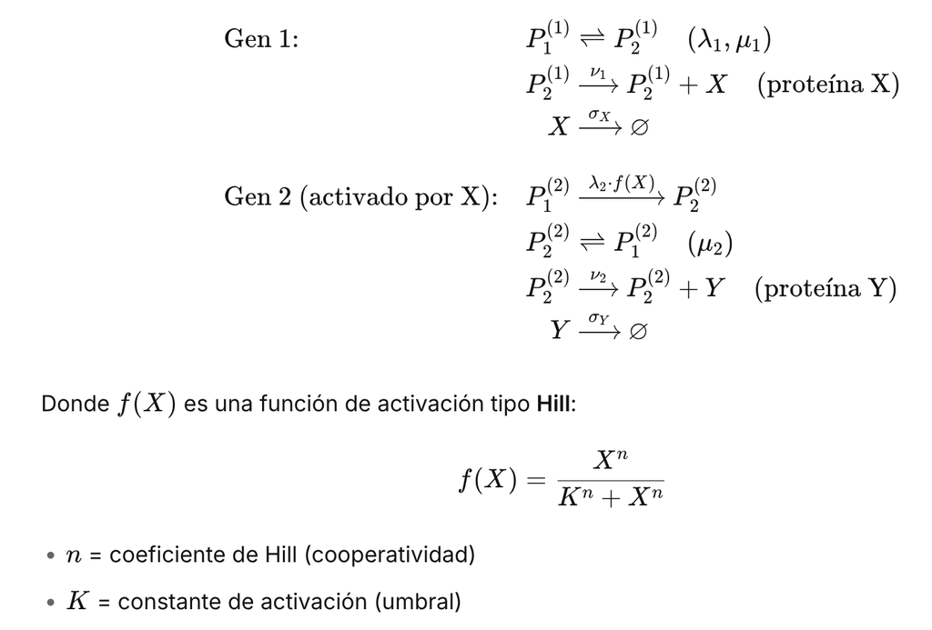

**¿Qué emerge biológicamente?**

Ruido propagado: el ruido de X "contagia" al gen 2 → fluctuaciones correlacionadas.

Interruptores biestables (si n ≥ 2 y hay retroalimentación positiva).

Oscilaciones si hay retardo en la retroalimentación.

Filtrado de ruido si la función Hill es suave.

```python
# ================================================================
#  RED GÉNICA ACOPLADA: cascada de 2 genes con activación Hill
#  8 reacciones → perfecto para probar que el Método Directo escala mejor
# ================================================================
import numpy as np
import matplotlib.pyplot as plt
from numba import njit
from ipywidgets import interact, FloatSlider, IntSlider, Checkbox
from scipy.integrate import odeint

# ----------------------------------------------------------------
#  Estado: [P1_1, P2_1, X, P1_2, P2_2, Y]  (6 especies)
#  Reacciones:
#   1) activación gen 1      : P1_1 -> P2_1     a = λ1 * P1_1
#   2) inactivación gen 1    : P2_1 -> P1_1     a = μ1 * P2_1
#   3) síntesis X            : P2_1 -> P2_1+X   a = ν1 * P2_1
#   4) degradación X         : X -> ∅           a = σX * X
#   5) activación gen 2      : P1_2 -> P2_2     a = λ2 * f(X) * P1_2
#   6) inactivación gen 2    : P2_2 -> P1_2     a = μ2 * P2_2
#   7) síntesis Y            : P2_2 -> P2_2+Y   a = ν2 * P2_2
#   8) degradación Y         : Y -> ∅           a = σY * Y
# ----------------------------------------------------------------

@njit(cache=True)
def hill(x, K, n):
    """Activación tipo Hill: X^n / (K^n + X^n)"""
    if x <= 0.0:
        return 0.0
    xn = x ** n
    return xn / (K ** n + xn)


@njit(cache=True)
def gillespie_two_genes(lam1, mu1, nu1, sigX,
                        lam2, mu2, nu2, sigY,
                        K_hill, n_hill,
                        t_max, seed):
    """Simulación estocástica de la cascada de dos genes."""
    np.random.seed(seed)

    max_steps = 2_000_000
    times = np.empty(max_steps, dtype=np.float64)
    S     = np.empty((max_steps, 6), dtype=np.int64)

    # Estado inicial: ambos genes inactivos, sin proteínas
    #  [P1_1, P2_1, X, P1_2, P2_2, Y]
    state = np.array([1, 0, 0, 1, 0, 0], dtype=np.int64)

    t = 0.0
    n = 0
    times[0] = 0.0
    S[0] = state

    while n < max_steps - 1:
        P1_1, P2_1, X, P1_2, P2_2, Y = state

        a1 = lam1 * P1_1
        a2 = mu1  * P2_1
        a3 = nu1  * P2_1
        a4 = sigX * X
        a5 = lam2 * hill(X, K_hill, n_hill) * P1_2
        a6 = mu2  * P2_2
        a7 = nu2  * P2_2
        a8 = sigY * Y

        a_tot = a1 + a2 + a3 + a4 + a5 + a6 + a7 + a8
        if a_tot <= 0.0:
            break

        r1 = np.random.random()
        r2 = np.random.random()
        tau   = -np.log(1.0 - r1) / a_tot
        t_new = t + tau

        if t_new > t_max:
            n += 1
            times[n] = t_max
            S[n] = state
            break

        target = r2 * a_tot
        if   target < a1:                  state[0] -= 1; state[1] += 1  # gen1 activo
        elif target < a1 + a2:             state[1] -= 1; state[0] += 1  # gen1 inactivo
        elif target < a1 + a2 + a3:        state[2] += 1                 # X sintetizada
        elif target < a1 + a2 + a3 + a4:   state[2] -= 1                 # X degradada
        elif target < a1 + a2 + a3 + a4 + a5:
                                            state[3] -= 1; state[4] += 1  # gen2 activo
        elif target < a1 + a2 + a3 + a4 + a5 + a6:
                                            state[4] -= 1; state[3] += 1  # gen2 inactivo
        elif target < a1 + a2 + a3 + a4 + a5 + a6 + a7:
                                            state[5] += 1                 # Y sintetizada
        else:                                state[5] -= 1                 # Y degradada

        t = t_new
        n += 1
        times[n] = t
        S[n] = state

    return times[:n+1], S[:n+1]


# ----------------------------------------------------------------
#  VERSIÓN DETERMINISTA (para comparar)
# ----------------------------------------------------------------
def two_genes_ode(y, t, lam1, mu1, nu1, sigX,
                  lam2, mu2, nu2, sigY, K, n):
    P1_1, P2_1, X, P1_2, P2_2, Y = y
    fX = (X**n) / (K**n + X**n) if X > 0 else 0.0
    dP1_1 = -lam1*P1_1 + mu1*P2_1
    dP2_1 =  lam1*P1_1 - mu1*P2_1
    dX    =  nu1*P2_1  - sigX*X
    dP1_2 = -lam2*fX*P1_2 + mu2*P2_2
    dP2_2 =  lam2*fX*P1_2 - mu2*P2_2
    dY    =  nu2*P2_2 - sigY*Y
    return [dP1_1, dP2_1, dX, dP1_2, dP2_2, dY]


# ----------------------------------------------------------------
#  VISUALIZACIÓN INTERACTIVA
# ----------------------------------------------------------------
def plot_two_genes(lam1, mu1, nu1, sigX,
                   lam2, mu2, nu2, sigY,
                   K_hill, n_hill,
                   t_max, seed, show_deterministic):
    seed = int(seed)

    # ---- Estocástico ----
    t_s, S = gillespie_two_genes(lam1, mu1, nu1, sigX,
                                 lam2, mu2, nu2, sigY,
                                 K_hill, n_hill,
                                 float(t_max), seed)

    # ---- Determinista ----
    t_d = np.linspace(0, t_max, 2000)
    y0  = [1, 0, 0, 1, 0, 0]
    sol = odeint(two_genes_ode, y0, t_d,
                 args=(lam1, mu1, nu1, sigX, lam2, mu2, nu2, sigY, K_hill, n_hill))

    # ---- Figura ----
    fig, axes = plt.subplots(2, 2, figsize=(15, 9))

    # --- Panel A: trayectorias estocásticas de X y Y ---
    ax = axes[0, 0]
    ax.step(t_s, S[:, 2], where='post', color='teal',   lw=1.4, label='X (proteína 1)')
    ax.step(t_s, S[:, 5], where='post', color='crimson',lw=1.4, label='Y (proteína 2)')
    if show_deterministic:
        ax.plot(t_d, sol[:, 2], '--', color='navy', lw=2, alpha=0.7,
                label='X (determinista)')
        ax.plot(t_d, sol[:, 5], '--', color='darkred', lw=2, alpha=0.7,
                label='Y (determinista)')
    ax.set_xlabel('Tiempo (s)'); ax.set_ylabel('Nº de moléculas')
    ax.set_title('Cascada génica: X → activa → Y', fontweight='bold')
    ax.legend(); ax.grid(True, alpha=0.3)

    # --- Panel B: retrato de fase X vs Y ---
    ax = axes[0, 1]
    ax.plot(S[:, 2], S[:, 5], color='purple', lw=0.9, alpha=0.7)
    ax.scatter(S[0, 2], S[0, 5], color='black', s=60, zorder=5, label='Inicio')
    ax.scatter(S[-1, 2], S[-1, 5], color='gold', s=80, edgecolor='black',
               zorder=5, label='Fin')
    ax.set_xlabel('X (moléculas)'); ax.set_ylabel('Y (moléculas)')
    ax.set_title('Retrato de fase (X, Y)', fontweight='bold')
    ax.legend(); ax.grid(True, alpha=0.3)

    # --- Panel C: estados de los genes ---
    ax = axes[1, 0]
    ax.step(t_s, S[:, 1], where='post', color='purple',   lw=1.2, label='Gen1 activo')
    ax.step(t_s, S[:, 4], where='post', color='darkorange',lw=1.2, label='Gen2 activo')
    ax.set_xlabel('Tiempo (s)'); ax.set_ylabel('Copias activas')
    ax.set_title('Estado de los promotores', fontweight='bold')
    ax.legend(); ax.grid(True, alpha=0.3)

    # --- Panel D: correlación X vs Y ---
    ax = axes[1, 1]
    hb = ax.hexbin(S[:, 2], S[:, 5], gridsize=25, cmap='viridis', mincnt=1)
    ax.set_xlabel('X (moléculas)'); ax.set_ylabel('Y (moléculas)')
    ax.set_title('Densidad conjunta (X, Y)', fontweight='bold')
    plt.colorbar(hb, ax=ax, label='Densidad')
    rho = np.corrcoef(S[:, 2], S[:, 5])[0, 1]
    ax.text(0.05, 0.95, f'ρ(X,Y) = {rho:.3f}',
            transform=ax.transAxes, fontsize=11, fontweight='bold',
            bbox=dict(boxstyle='round', facecolor='white', alpha=0.9))

    plt.tight_layout(); plt.show()

    # ---- Diagnóstico ----
    print("─── Diagnóstico de la red acoplada ───")
    print(f"  Media X    = {S[:,2].mean():7.3f}  ± {S[:,2].std():6.3f}")
    print(f"  Media Y    = {S[:,5].mean():7.3f}  ± {S[:,5].std():6.3f}")
    print(f"  Correlación ρ(X, Y) = {rho:.4f}")
    if abs(rho) > 0.5:
        print("  → Ruido propagado FUERTEMENTE del gen 1 al gen 2")
    elif abs(rho) > 0.2:
        print("  → Ruido parcialmente propagado")
    else:
        print("  → Genes prácticamente desacoplados por el ruido")


# ---- Widget ----
interact(plot_two_genes,
         lam1 = FloatSlider(value=1.0,  min=0.2,  max=3.0,  step=0.1,  description='λ₁ (gen1):'),
         mu1  = FloatSlider(value=5.0,  min=1.0,  max=10.0, step=0.5,  description='μ₁:'),
         nu1  = FloatSlider(value=2.0,  min=0.2,  max=5.0,  step=0.2,  description='ν₁ (sínt. X):'),
         sigX = FloatSlider(value=0.10, min=0.02, max=0.50, step=0.02, description='σ_X:'),
         lam2 = FloatSlider(value=2.0,  min=0.2,  max=5.0,  step=0.1,  description='λ₂ (gen2):'),
         mu2  = FloatSlider(value=5.0,  min=1.0,  max=10.0, step=0.5,  description='μ₂:'),
         nu2  = FloatSlider(value=2.0,  min=0.2,  max=5.0,  step=0.2,  description='ν₂ (sínt. Y):'),
         sigY = FloatSlider(value=0.10, min=0.02, max=0.50, step=0.02, description='σ_Y:'),
         K_hill=FloatSlider(value=15.0, min=1.0,  max=100., step=1.0,  description='K (Hill):'),
         n_hill=FloatSlider(value=2.0,  min=1.0,  max=4.0,  step=1.0,  description='n (Hill):'),
         t_max= FloatSlider(value=100,  min=20,   max=500,  step=10,   description='t_max (s):'),
         seed = IntSlider(value=7,      min=0,    max=999,  step=1,    description='Semilla:'),
         show_deterministic=Checkbox(value=True, description='Mostrar determinista'));
```

```
interactive(children=(FloatSlider(value=1.0, description='λ₁ (gen1):', max=3.0, min=0.2), FloatSlider(value=5.…
```

## Qué explorar

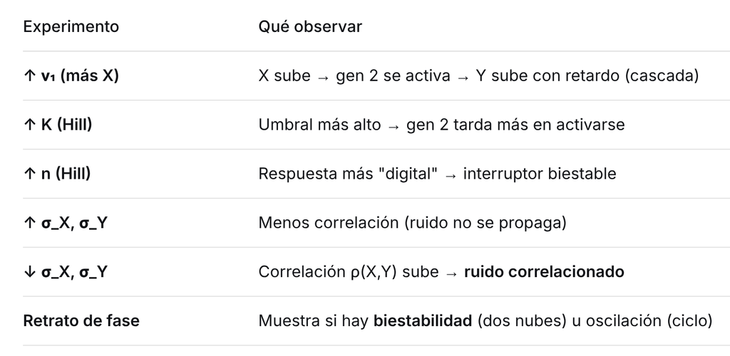

**Aplicación real:** así se modelan cascadas como NF-κB → TNF, MAPK/ERK, o los circuitos toggle-switch de biología sintética (Gardner et al., Nature 2000).